# Dictionary methods - advanced topics

Pablo Barbera

```r
library(quanteda)
```

## Creating your own dictionary

Dictionaries are named lists, consisting of a “key” and a set of entries defining the equivalence class for the given key. To create a simple dictionary of parts of speech, for instance, we could define a dictionary consisting of articles and conjunctions, using the `dictionary()` constructor

```r
posDict <- dictionary(list(articles = c("the", "a", "an"),
                           conjunctions = c("and", "but", "or", "nor", "for", "yet", "so")))
```

You can examine this dictionary by invoking its `print` method, simply by typing the name of the object and pressing Enter. The dictionary is stored as an S4 class object of type `dictionary2`. This means that this class is an extension of the `list` class. In other words, the dictionary is internally stored as a nested list.

```r
str(posDict)
```

```
## Formal class 'dictionary2' [package "quanteda"] with 2 slots
##   ..@ .Data       :List of 2
##   .. ..$ :List of 1
##   .. .. ..$ : chr [1:3] "the" "a" "an"
##   .. ..$ :List of 1
##   .. .. ..$ : chr [1:7] "and" "but" "or" "nor" ...
##   ..@ concatenator: chr " "
```

```r
getClass("dictionary2")
```

```
## Class "dictionary2" [package "quanteda"]
##
## Slots:
##
## Name:         .Data concatenator
## Class:         list    character
##
## Extends:
## Class "list", from data part
## Class "vector", by class "list", distance 2
```

Let’s create a DFM with the `data_corpus_inaugural` corpus (which comes with quanteda) and apply the dictionary.

```r
posDfm <- dfm(data_corpus_inaugural, dictionary = posDict)
head(posDfm)
```

```
## Document-feature matrix of: 6 documents, 2 features (0.0% sparse).
## 6 x 2 sparse Matrix of class "dfm"
##                  features
## docs              articles conjunctions
##   1789-Washington      140           73
##   1793-Washington       14            4
##   1797-Adams           232          192
##   1801-Jefferson       154          109
##   1805-Jefferson       168          126
##   1809-Madison         128           63
```

If we plot the values of articles and conjunction over the time (across the speeches) we see taht there is a lot of variation. The reason for that is that the raw number of articles and conjunctions will be a function of document length.

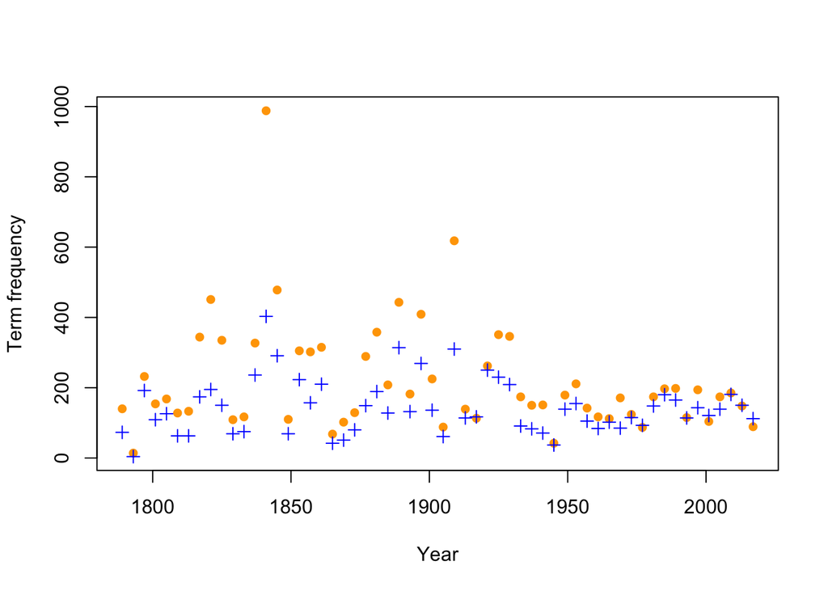

```r
plot(x = docvars(data_corpus_inaugural, "Year"),
     y = posDfm[, "articles"],
     type = "p", pch = 16, col = "orange",
     ylim = range(posDfm),
     xlab = "Year", ylab = "Term frequency")
points(x = docvars(data_corpus_inaugural, "Year"),
     y = posDfm[, "conjunctions"],
     pch = 3, col = "blue", new = FALSE)
```

If we replicate the graph, but this time using weights in the `posDfm` that take into account the differences in the length of each speech, we still find a similar pattern: usage of articles vs conjunctions is not stable over time.

During the 19th century the usage is more or less stable but then the relative importance of conjunctions compared to articles increases more and more. Since the 1990s both types of function words seem to be used about equally. This probably has to do with the fact that recent speeches have been shown on TV, with more frequent pauses for applause, which means presidents probably prefer to speak in shorter, simpler sentences.

```r
posDfmWeight <- dfm_weight(posDfm, scheme = "prop")
head(posDfmWeight)
```

```
## Document-feature matrix of: 6 documents, 2 features (0.0% sparse).
## 6 x 2 sparse Matrix of class "dfm"
##                  features
## docs               articles conjunctions
##   1789-Washington 0.6572770    0.3427230
##   1793-Washington 0.7777778    0.2222222
##   1797-Adams      0.5471698    0.4528302
##   1801-Jefferson  0.5855513    0.4144487
##   1805-Jefferson  0.5714286    0.4285714
##   1809-Madison    0.6701571    0.3298429
```

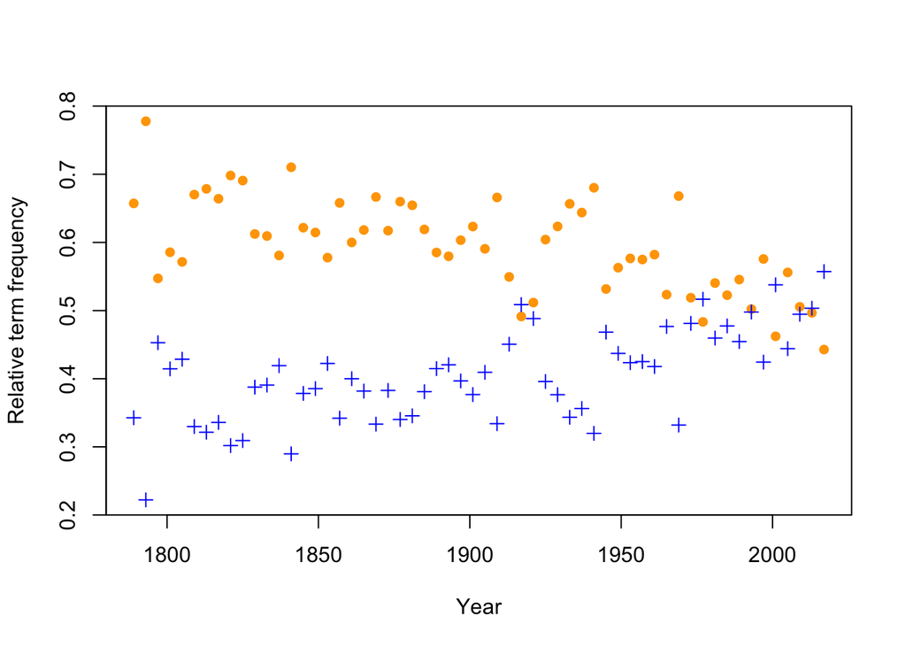

```r
# base R plot
plot(x = docvars(data_corpus_inaugural, "Year"),
     y = posDfmWeight[, "articles"],
     type = "p", pch = 16, col = "orange",
     ylim = range(posDfmWeight),
     xlab = "Year", ylab = "Relative term frequency")
points(x = docvars(data_corpus_inaugural, "Year"),
     y = posDfmWeight[, "conjunctions"],
     pch = 3, col = "blue", new = FALSE)
```

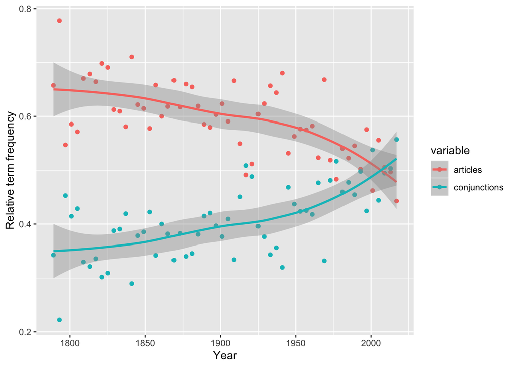

```r
# Plot with easier to see trends
library(ggplot2)
library(reshape2)
pdw <- convert(posDfmWeight, to="data.frame")
pdw$year <- as.numeric(substr(pdw$document, 1, 4))
pdw <- melt(pdw, id.vars = c("year", "document"))
ggplot(pdw, aes(x = year, y = value, colour = variable)) +
  geom_point() +
  geom_smooth(method = "loess") +
  labs(x = "Year", y = "Relative term frequency")
```

## Hierarchical dictionaries.

Dictionaries may also be hierarchical, where a top-level key can consist of subordinate keys, each a list of its own. For instance, `list(articles = list(definite="the", indefinite=c("a", "an"))` defines a valid list for articles.

Let’s explore this idea by creating a dictionary of articles and conjunctions with two levels, one for definite and indefinite articles, and one for coordinating and subordinating conjunctions.

```r
posDictHier <- list(
  article = list(definite = "the", indefinite = c("a", "an")),
  conjunction = list(
    coordinating = c("and", "but", "or", "nor", "for", "yet", "so"),
    subordinating = c("although", "because", "since", "unless")
  )
)
```

Now let’s apply this to the `data_corpus_inaugural` object, and examine the resulting features.

```r
posDfmHier <- dfm(data_corpus_inaugural, dictionary = dictionary(posDictHier))
head(posDfmHier)
```

```
## Document-feature matrix of: 6 documents, 4 features (8.33% sparse).
## 6 x 4 sparse Matrix of class "dfm"
##                  features
## docs              article.definite article.indefinite
##   1789-Washington              116                 24
##   1793-Washington               13                  1
##   1797-Adams                   163                 69
##   1801-Jefferson               130                 24
##   1805-Jefferson               143                 25
##   1809-Madison                 104                 24
##                  features
## docs              conjunction.coordinating conjunction.subordinating
##   1789-Washington                       73                         4
##   1793-Washington                        4                         0
##   1797-Adams                           192                         1
##   1801-Jefferson                       109                         0
##   1805-Jefferson                       126                         3
##   1809-Madison                          63                         2
```

What happened to the hierarchies, to make them into “features”? The different levels are joined by a dot (“.”).

Do the subcategories sum to the two general categories? Let’s double check…

```r
posDfmHierAlt <- dfm_lookup(posDfmHier, dictionary = dictionary(list(
  article = c("article.definite", "article.indefinite"),
  conjunction = c("conjunction.coordinating", "conjunction.subordinating")
)))
head(posDfmHierAlt)
```

```
## Document-feature matrix of: 6 documents, 2 features (0.0% sparse).
## 6 x 2 sparse Matrix of class "dfm"
##                  features
## docs              article conjunction
##   1789-Washington     140          77
##   1793-Washington      14           4
##   1797-Adams          232         193
##   1801-Jefferson      154         109
##   1805-Jefferson      168         129
##   1809-Madison        128          65
```

```r
head(posDfm)
```

```
## Document-feature matrix of: 6 documents, 2 features (0.0% sparse).
## 6 x 2 sparse Matrix of class "dfm"
##                  features
## docs              articles conjunctions
##   1789-Washington      140           73
##   1793-Washington       14            4
##   1797-Adams           232          192
##   1801-Jefferson       154          109
##   1805-Jefferson       168          126
##   1809-Madison         128           63
```

Note that for the article category they do but not for the conjunctions. This is to be expected as in the first version (`posDfm`) only coordinating conjunctions were included whereas the hierarchical categories also contains subordinating conjunctions.

### Thesauruses

A “thesaurus” is a list of feature equivalencies specified in the same list format as a dictionary, but with a key difference. Which one? Let’s find out.

If we wanted to count pronouns as equivalent, for instance, we could use the thesaurus argument to `dfm` in order to group all listed prounouns into a single feature labelled “PRONOUN”.

```r
mytexts <- c("We love USC.", "I bought myself a new car.")
myThes <- dictionary(list(pronouns = list(firstp = c("I", "me", "my", "mine", "myself", "we", "us", "our", "ours"))))
myDfm <- dfm(mytexts, thesaurus = myThes)
myDfm
```

```
## Document-feature matrix of: 2 documents, 8 features (37.5% sparse).
## 2 x 8 sparse Matrix of class "dfm"
##        features
## docs    PRONOUNS.FIRSTP love usc . bought a new car
##   text1               1    1   1 1      0 0   0   0
##   text2               2    0   0 1      1 1   1   1
```

Notice how the thesaurus key has been made into uppercase—this is to identify it as a key, as opposed to a word feature from the original text.

However, note a key difference with respect to dictionaries: the features that are not matched to dictionary entries are retained.

```r
myDfmFunc <- dfm(mytexts, thesaurus = posDict)
myDfmFunc
```

```
## Document-feature matrix of: 2 documents, 10 features (45.0% sparse).
## 2 x 10 sparse Matrix of class "dfm"
##        features
## docs    ARTICLES we love usc . i bought myself new car
##   text1        0  1    1   1 1 0      0      0   0   0
##   text2        1  0    0   0 1 1      1      1   1   1
```